# Pragmatic metadata management for integration into multiple spatial data infrastructure systems and platforms

Karl Benedict <sup>1</sup>

Soren Scott <sup>2</sup>

11-Dec-2013. AGU Fall Meeting, San Francisco, CA (http://tinyurl.com/qgelppl)

# Introduction

> prag·mat·ic *adjective* `\prag-'ma-tik\` : dealing with the problems that exist in a specific situation in a reasonable and logical way instead of depending on ideas and theories

— [Merriam-Webster Dictionary](http://www.merriam-webster.com/dictionary/pragmatic)

## Abstract

While there has been a convergence towards a limited number of standards for representing knowledge (metadata) about geospatial (and other) data objects and collections, there exist a variety of community conventions around the specific use of those standards and within specific data discovery and access systems. This combination of limited (but multiple) standards and conventions creates a challenge for system developers that aspire to participate in multiple data infrastrucutres, each of which may use a different combination of standards and conventions. While Extensible Markup Language (XML) is a shared standard for encoding most metadata, traditional direct XML transformations (XSLT) from one standard to another often result in an imperfect transfer of information due to incomplete mapping from one standard’s content model to another.

This paper presents the work at the University of New Mexico’s Earth Data Analysis Center (EDAC) in which a unified data and metadata management system has been developed in support of the storage, discovery and access of heterogeneous data products. This sytem, the Geographic Storage, Transformation and Retrieval Engine (GSTORE) platform has adopted a polyglot database model in which a combination of relational and document-based databases are used to store both data and metadata, with some metadata stored in a custom XML schema designed as a superset of the requirements for multiple target metadata standards: ISO 19115-2/19139/19110/19119, FGCD CSDGM (both with and without remote sensing extensions) and Dublin Core. Metadata stored within this schema is complemented by additional service, format and publisher information that is dynamically “injected” into produced metadata documents when they are requested from the system. While mapping from the underlying common metadata schema is relatively straightforward, the generation of valid metadata within each target standard is necessary but not sufficient for integration into multiple data infrastructures, as has been demonstrated through EDAC’s testing and deployment of metadata into multiple external systems: Data.Gov, the GEOSS Registry, the DataONE network, the DSpace based institutional repository at UNM and semantic mediation systems developed as part of the NASA ACCESS ESLeWEB project. Each of these systems requires valid metadata as a first step, but to make most effective use of the delivered metadata each also has a set of conventions that are specific to the system. This presentation will provide an overview of the underlying metadata management model, the processes and web services that have been developed to automatically generate metadata in a variety of standard formats and highlight some of the specific modifications made to the output metadata content to support the different conventions used by the multiple metadata integration endpoints.

## Organizational Foundation

EDAC specializes in applied geographic information technologies across multiple research and applications domains including public health; disaster planning, management and mitigation; natural resources management; broadband network distribution analysis and mapping; data archival and clearinghouse services and research cyberinfrastructure. Historically EDAC has managed work in these domains as separate projects, often built upon vertically integrated data management, discovery and access systems as appropriate for a given project. Over the last 5 years EDAC has developed a unified data management, discovery and access platform (the Geographic Storage, Transformation and Retrieval Engine - GSTORE) that is under continuous development in support of broadening its utility across multiple projects and use cases.

# Background - Diversity of data

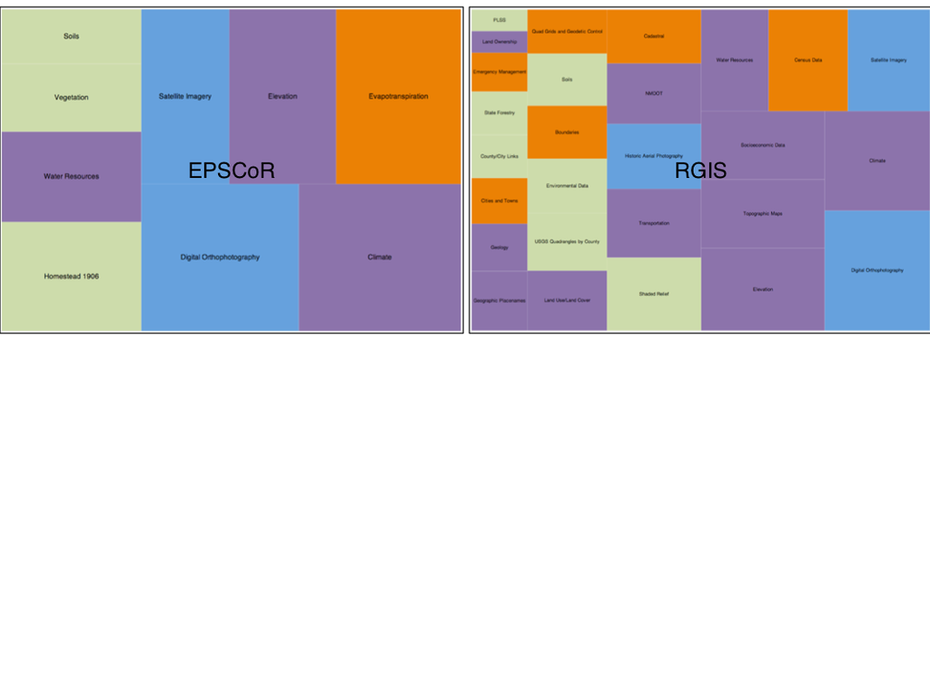

Illustration of the diversity of data classes in two project collections

While the project contexts within which EDAC works are commonly geospatial, the types of data, their structure and format, and subject are highly variable.

# Background - Diversity of systems to integrate with

The requirements of different projects have led to a need to integrate data products, services **and their metadata** into multiple systems, including

- Project specific data portals such as the New Mexico EPSCoR [data portal](http://nmepscor.unm.edu/dataportal/browse) and the New Mexico Resource Geographic Information System ([NM RGIS](http://rgis.unm.edu))
- Geospatial OneStop (subsequently replaced by *geo.data.gov* and then by [*catalog.data.gov*](http://catalog.data.gov)
- The Global Earth Observation System of Systems (GEOSS) [Components and Services Registry](http://www.earthobservations.org/gci_cr.shtml)
- [DataONE](http://www.dataone.org/)
- [CUAHSI](http://www.cuahsi.org/)
- [LoboVault](http://repository.unm.edu/) - UNM’s institutional repository

# Background - Diversity of data, metadata and service formats and standards

Data, metadata and service standards currently supported by GSTORE

| Metadata | Vectors | Rasters | Files | Services |
| --- | --- | --- | --- | --- |
| *FGDC CSDGM* | SHP | GeoTIFF | ZIP | WMS |
| *FGDC CSDGM-RSE* | KML | IMG | HTML | WFS |
| *ISO 19115-2 / 19139* | GML | SID | PDF | WCS |
| *ISO 19119* | GeoJSON | ECW | DOC/DOCX |  |
| *ISO 19110* | JSON | DEM | GZ |  |
|  | XLS | ASCII | XLS/XLSX |  |
|  | CSV |  | PPT/PPTX |  |

# High-level Architecture - Overall View

[figure not shown]

Overall Architectural Diagram

# High-level Architecture - Highlighted Elements

[figure not shown]

Highlighted Architectural Diagram

# Process Overview

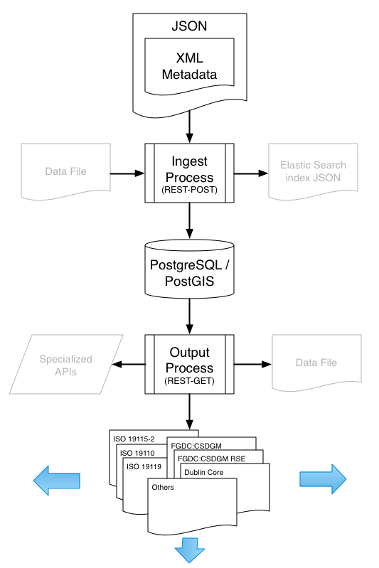

Overview of the Combined Ingest and Metadata Generation Process

The overall GSTORE metadata processing workflow consists of the following high-level steps:

- Submission of a JSON document containing an embedded XML (ISO, FGDC or GSTORE) metadata record via the GSTORE API
- Processing of the submitted JSOM document into the PostgreSQL database
- Generation and delivery of metadata in a variety of formats in response to GSTORE web service requests

# Process - Ingest

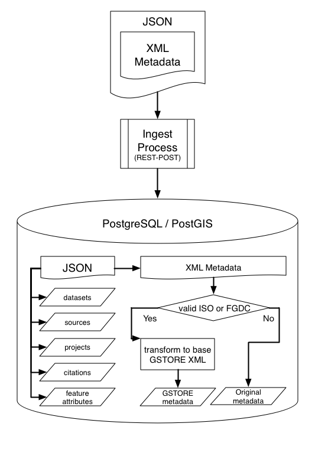

Detailed View of the Metadata/data Ingest Process

The ingest proces consists of parsing the submitted JSON package and adding its contents to various locations within the GSTORE database

- If the JSON document contains valid FGDC or ISO metadata it is transformed into GSTORE metadata and stored. Otherwise, the embedded XML document is stored as the *original* metadata record
- Other elements of the JSON document are written into multiple tables in the database.

# Process - Export

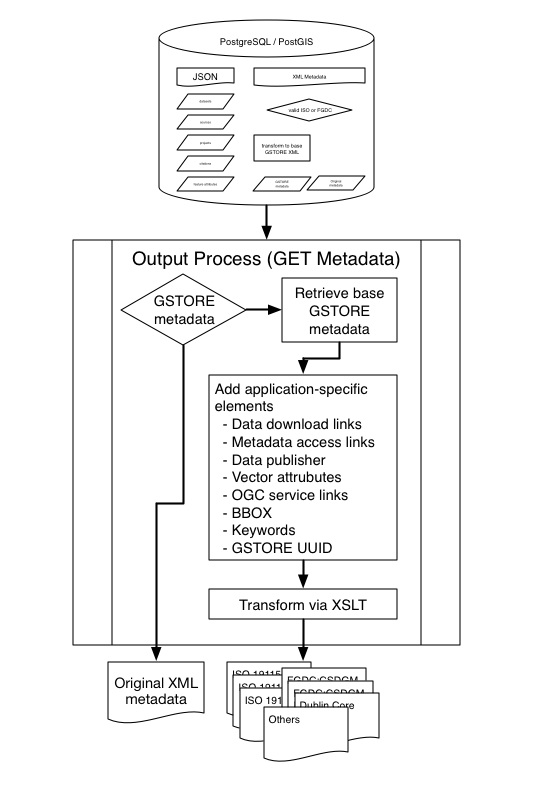

Overview of the Metadata Generation Process

Supported Output Formats

- FGDC CSDGM & CSDGM-RSE
- ISO
  - 19115-2 / 19139 (MI- and DS-)
  - 19110 (vector data feature catalog)
  - 19119 (OGC WxS)
- Dublin Core
- Schema.org within HTML renderings
- Elastic Search JSON documents for indexing/search
- EML (early development)
- [Project Open Data](http://project-open-data.github.io/) (early development)

# Integration into other Systems

The system is currently operational or in testing with:

- Catalog.data.gov
- GEOSS Components and Services Registry
- DataONE Tier 1 Member Node
- ElseWEB semantic mediation system

Internal development under way:

- CUAHSI WaterML
- DataONE Tier 4 Member Node
- Catalog.data.gov collection integration (ISO DS metadata records)
- W3C PROV services

# High-level View of GSTORE Metadata XML

```
<metadata>
    <original>...</original>
    <identification dataset="51349b33-92eb-4ab8-9217-81c82b5c3afa">...</identification>
    <constraints>...</constraints>
    <spatial>...</spatial>
    <quality>...</quality>
    <lineage>...</lineage>
    <attributes>...</attributes>
    <metadata>...</metadata>
    <distribution>...</distribution>
    <contacts>...</contacts>
    <citations>...</citations>
    <sources>...</sources>
</metadata>
```

# Sample Requests - *Digital Geologic Map of New Mexico - Formations*

**GSTORE Metadata - XML**

http://gstore.unm.edu/apps/rgis/datasets/51349b33-92eb-4ab8-9217-81c82b5c3afa/metadata/GSTORE.xml

**FGDC CSDGM 1998 - XML**

http://gstore.unm.edu/apps/rgis/datasets/51349b33-92eb-4ab8-9217-81c82b5c3afa/metadata/FGDC-STD-001-1998.xml

**FGDC CSDGM 1998 - HTML with Schema.org additions**

http://gstore.unm.edu/apps/rgis/datasets/51349b33-92eb-4ab8-9217-81c82b5c3afa/metadata/FGDC-STD-001-1998.html

**ISO 19115-2 (19139) - XML**

http://gstore.unm.edu/apps/rgis/datasets/51349b33-92eb-4ab8-9217-81c82b5c3afa/metadata/ISO-19115:2003.xml

**ISO 19115-2 (19139) - HTML with Schema.org additions**

http://gstore.unm.edu/apps/rgis/datasets/51349b33-92eb-4ab8-9217-81c82b5c3afa/metadata/ISO-19115:2003.html

**ISO 19110 (Feature Catalog) - XML**

http://gstore.unm.edu/apps/rgis/datasets/51349b33-92eb-4ab8-9217-81c82b5c3afa/metadata/ISO-19110.xml

**ISO 19119 (Service metadata) - XML for OGC WFS service**

http://gstore.unm.edu/apps/rgis/datasets/51349b33-92eb-4ab8-9217-81c82b5c3afa/metadata/ISO-19119:WFS.xml

**ISO 19119 (Service metadata) - XML for OGC WMS service**

http://gstore.unm.edu/apps/rgis/datasets/51349b33-92eb-4ab8-9217-81c82b5c3afa/metadata/ISO-19119:WMS.xml

# Lessons Learned & Next Steps

- There is a significant difference between *valid* and *useful* metadata
- Metadata development is an iterative process
- Implementation of new output formats is a relatively fast and straightforward process
- Regenerating new collections of metadata with updated autogenerated content not as fast - over 285k data objects currently managed in GSTORE

# Resources

- GSTORE XSLT/XSD Github Collection: https://github.com/edac/metadata/tree/master/gstore
- GSTORE API Reference: http://gstore.unm.edu/
- Presentation Materials
  - Handout (HTML) - http://karlbenedict.com/presentations/2013-12-agu/presentation.handout.html
  - Handout (PDF) - http://karlbenedict.com/presentations/2013-12-agu/presentation.handout.pdf
  - Slides (HTML) - http://karlbenedict.com/presentations/2013-12-agu/presentation.slides.html

# Key Acronyms

**ISO**

International Standards Organization

**FGDC CSDGM (RSE)**

Federal Geographic Data Committee Content Standard for Digital Geospatial Metadata (Remote Sensing Extension)

**JSON**

Javascript Object Notation

**XMK**

Extensible Markup Language

**API**

Application Programming Interface

**OGC**

Open Geospatial Consortium

**WMS, WFS, WCS**

OGC Web Map/Feature/Coverage Service

# Acknowledgements

This work has been funded in part through the support of:

- NASA: ACCESS-11-0018 NNX12AF49A
- NSF
  - Energize New Mexico - #1301346
  - New Mexico EPSCoR RII3: Climate Change Impacts on New Mexico’s Mountain Sources of Water - #0814449
  - Collaborative Research: Cyberinfrastructure Development in the Western Consortium of Idaho, Nevada, and New Mexico - #0918635
  - Collaborative Research: Western Consortium for Watershed Analysis, Visualization, and Exploration (WC-WAVE) - #1329470
  - Collaborative Research: CI-Team Diff: The Virtual Learning Commons: STEM Research Communities Learning about Data Management, Geospatial Informatics, and Scientific Visualization - #OCI-1135530
- New Mexico RGIS Program - New Mexico State Legislature

# Questions?

[^1]: University of New Mexico, Earth Data Analysis Center, University Libraries, Department of Geography - kbene@unm.edu
[^2]: University of New Mexico, Earth Data Analysis Center